# Chi-square Test

## What is the Chi-Square Test?

The Chi-Square Test of Independence helps us answer:

- Is there a relationship between two categorical variables?
- Or are they independent?

It compares the observed frequencies (what we actually see) to the expected frequencies (what we would expect if the variables were not related).

```r
library(palmerpenguins)
library(ggplot2)
library(dplyr)
library(ggrepel)
library(ggthemes)
```

## 📦 Example: Penguins on Islands

Let's take a look at our penguin dataset again. How are the penguins distributed in the three islands?

[figure not shown]

### Observed Frequencies (O)

```r
df <- na.omit(penguins)

# Create observed contingency table
penguin_table <- table(df$species, df$island)
as.data.frame.matrix(penguin_table)
```

A data.frame: 3 × 3

|  | Biscoe <int> | Dream <int> | Torgersen <int> |
| --- | --- | --- | --- |
| Adelie | 44 | 55 | 47 |
| Chinstrap | 0 | 68 | 0 |
| Gentoo | 119 | 0 | 0 |

It seems that there are some preferences of the penguins to live in a certain island? Don't you think so?

Let's test this question:

> **Is species distribution associated with the islands?**

### Expected Frequencies (E)

If there's no association, the penguins would be distributed proportionally in each island.

We can use this formula to calculate the expected frequency in each island.

$E_{ij} = \frac{(\text{row total}_i) \times (\text{column total}_j)}{\text{grand total}}$

So the Expected Table is:

```r
# Get totals
row_totals <- rowSums(penguin_table)
col_totals <- colSums(penguin_table)
grand_total <- sum(penguin_table)

# Manually compute expected frequency matrix
expected_matrix <- outer(row_totals, col_totals, FUN = function(r, c) (r * c) / grand_total)

# Round to nearest integer
expected_matrix <- round(expected_matrix)

# Assign row and column names
rownames(expected_matrix) <- rownames(penguin_table)
colnames(expected_matrix) <- colnames(penguin_table)

# View expected frequencies
expected_matrix
```

A matrix: 3 × 3 of type dbl

|  | Biscoe | Dream | Torgersen |
| --- | --- | --- | --- |
| Adelie | 71 | 54 | 21 |
| Chinstrap | 33 | 25 | 10 |
| Gentoo | 58 | 44 | 17 |

Let's compare the observed and expected values side by side:

```r
# Extract observed and expected
observed <- as.numeric(penguin_table)
expected <- as.numeric(expected_matrix)

# Combine into a data frame with labels
species <- rep(rownames(penguin_table), times = ncol(penguin_table))
island <- rep(colnames(penguin_table), each = nrow(penguin_table))

observation_table <- data.frame(
  Species = species,
  Island = island,
  Observed = observed,
  Expected = round(expected, 2)
)

observation_table
```

A data.frame: 9 × 4

| Species <chr> | Island <chr> | Observed <dbl> | Expected <dbl> |
| --- | --- | --- | --- |
| Adelie | Biscoe | 44 | 71 |
| Chinstrap | Biscoe | 0 | 33 |
| Gentoo | Biscoe | 119 | 58 |
| Adelie | Dream | 55 | 54 |
| Chinstrap | Dream | 68 | 25 |
| Gentoo | Dream | 0 | 44 |
| Adelie | Torgersen | 47 | 21 |
| Chinstrap | Torgersen | 0 | 10 |
| Gentoo | Torgersen | 0 | 17 |

## Calculating the Chi-square

The Chi-Square test statistic tells us **how different** the observed data is from what we would expect under the assumption that the two categorical variables are independent.

We use the following formula:

$$ \chi^2 = \sum \frac{(O - E)^2}{E} $$

Where:

- $( O )$ = observed frequency (what we actually counted)
- $( E )$ = expected frequency (what we would expect if there were no association)
- $( \chi^2 )$ = the total test statistic, measuring the overall difference between observed and expected

### 🔍 How does it work?

We go through each cell of the contingency table and compute:

$$ \frac{(O - E)^2}{E} $$

This value will be:

- **Close to 0** if observed and expected are similar
- **Larger** when there's a big difference between the two

Then we **sum up** all of these values from every cell to get the total Chi-Square statistic.

### 🎯 What does it tell us?

If the resulting $( \chi^2 )$ value is **large enough**, it means the differences between observed and expected are **too big to be due to random chance**.  
This suggests that the two variables (like *species* and *island*) are **likely associated**.

### 📊 Visualize O vs E

To help you better understand where the differences come from, you can make a bar plot comparing observed vs expected frequencies:

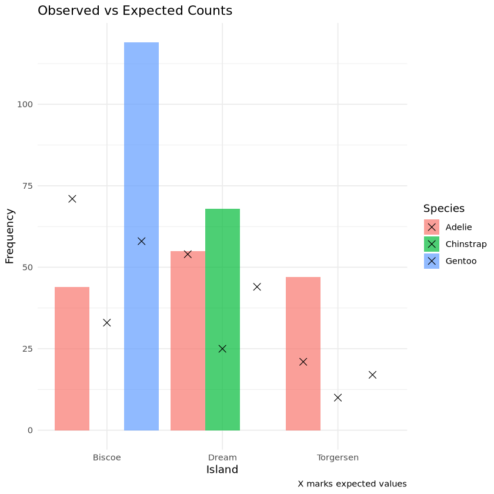

```r
ggplot(observation_table, aes(x = Island, fill = Species)) +
  geom_bar(aes(y = Observed), stat = "identity", position = "dodge", alpha = 0.7) +
  geom_point(aes(y = Expected), shape = 4, size = 3,
             position = position_dodge(width = 0.9)) +
  labs(title = "Observed vs Expected Counts",
       y = "Frequency", caption = "X marks expected values") +
  theme_minimal()
```

### Let's Calculate the Chi-Square value

Let's go through each cell of the contingency table and compute:

$$ \frac{(O - E)^2}{E} $$

And at the end, we will create a sum of all the component values

```r
# Calculate chi-square components: (O - E)^2 / E
component <- (observed - expected)^2 / expected

# Add to the data frame (round if desired)
observation_table$Component <- round(component, 2)

# View the updated table
observation_table

# Total chi-square statistic
cat("Total χ² =", round(sum(component), 2), "\n")
```

A data.frame: 9 × 5

| Species <chr> | Island <chr> | Observed <dbl> | Expected <dbl> | Component <dbl> |
| --- | --- | --- | --- | --- |
| Adelie | Biscoe | 44 | 71 | 10.27 |
| Chinstrap | Biscoe | 0 | 33 | 33.00 |
| Gentoo | Biscoe | 119 | 58 | 64.16 |
| Adelie | Dream | 55 | 54 | 0.02 |
| Chinstrap | Dream | 68 | 25 | 73.96 |
| Gentoo | Dream | 0 | 44 | 44.00 |
| Adelie | Torgersen | 47 | 21 | 32.19 |
| Chinstrap | Torgersen | 0 | 10 | 10.00 |
| Gentoo | Torgersen | 0 | 17 | 17.00 |

```
Total χ² = 284.59
```

### Degrees of Freedom

So, we got the χ² values, but how do we interpret it? Before we can interpret the value, first we need to calculate the degree of freedom first.

The degrees of freedom (df) for a Chi-Square test in a contingency table is calculated as:

$$ df = (\text{\#rows} - 1) \times (\text{\#columns} - 1) $$

In our case, there are 3 species (rows) and 3 islands (columns):

$$ df = (3 - 1)(3 - 1) = 2 \times 2 = 4 $$

We can use the df to find the critical value from a Chi-Square distribution table at a significance level of 0.05.

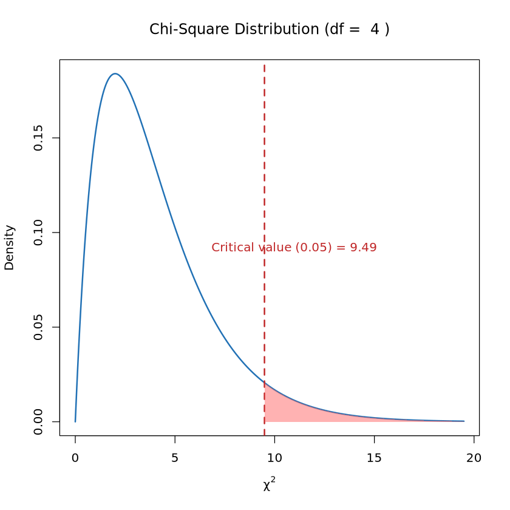

```r
# Parameters
df_val <- 4
alpha <- 0.05

# Critical value (right-tail threshold)
critical_value <- qchisq(p = 1 - alpha, df = df_val)

# Generate x and y for chi-square density curve
x <- seq(0, critical_value + 10, length.out = 500)
y <- dchisq(x, df = df_val)

# Plot the Chi-Square distribution
plot(x, y, type = "l", lwd = 2, col = "#2171B5",
     ylab = "Density", xlab = expression(chi^2),
     main = bquote("Chi-Square Distribution (df = " ~ .(df_val) ~ ")"))

# Add vertical line at critical value
abline(v = critical_value, col = "#c02728", lwd = 2, lty = 2)

# Shade the rejection region (right tail)
x_shade <- seq(critical_value, max(x), length.out = 100)
y_shade <- dchisq(x_shade, df = df_val)
polygon(c(critical_value, x_shade, max(x_shade)),
        c(0, y_shade, 0),
        col = "#FF666680", border = NA)

# Annotate the plot
text(critical_value + 1.5, max(y)*0.5,
     paste0("Critical value (0.05) = ", round(critical_value, 2)),
     col = "#c02728")
```

### Interpretation

Now we compare the calculated Chi-Square statistic to the critical value from a Chi-Square distribution table at a significance level of 0.05.

If:

- $( \chi^2 = 284.59 )$
- $( df = 4 )$
- Critical value at $( \alpha = 0.05 )$ is **9.49**

Then:

$$ 284.59 > 9.49 $$

So we **reject the null hypothesis**.

✅ **Conclusion**:

- There is a **statistically significant relationship** between penguin species and the islands where they are found.
- The distribution is **not uniform** and likely reflects ecological or behavioral preferences.

## Running chi-square test in R

R has a neat chi-square package, so we can directly use the library instead of calculating it manually:

```r
# Run the chi-square test
chi <- chisq.test(penguin_table)

chi
```

```
	Pearson's Chi-squared test

data:  penguin_table
X-squared = 284.59, df = 4, p-value < 2.2e-16
```

Let us also visualize the result:

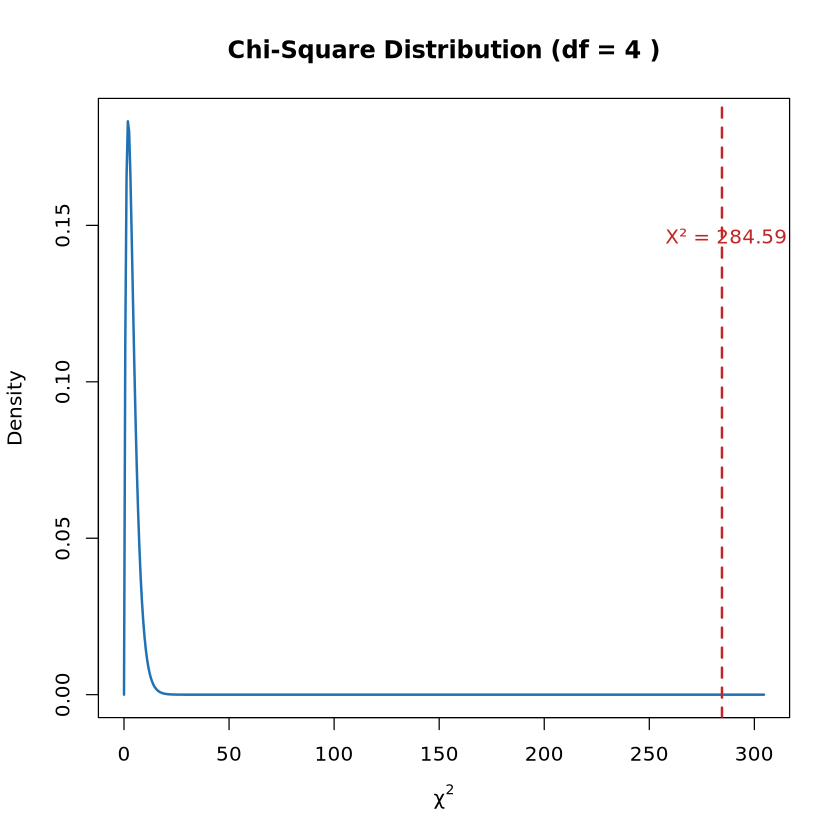

```r
# Extract test statistic and df
chi_stat <- chi$statistic
df_val <- chi$parameter

# Create x values for chi-square density
x <- seq(0, chi_stat + 20, length.out = 500)
y <- dchisq(x, df = df_val)

# Plot
plot(x, y, type = "l", lwd = 2, col = "#2171B5",
     ylab = "Density", xlab = expression(chi^2),
     main = paste("Chi-Square Distribution (df =", df_val, ")"))

# Add vertical line at test statistic
abline(v = chi_stat, col = "#c02728", lwd = 2, lty = 2)

# Annotate
text(chi_stat + 2, max(y)*0.8,
     labels = paste0("X² = ", round(chi_stat, 2)),
     col = "#c02728")
```